# Exploratory Analysis

Tessa Senders

12/11/2020

```r
library(tidyverse)
library(stringr)
library(leaps)
```

```r
hate_crimes_df <- read.csv("./data/HateCrimes.csv") %>%
  janitor::clean_names() %>%
  rename(perc_pop_hs = perc_population_with_high_school_degree) %>%
  mutate(hate_crimes_per_100k_splc = as.numeric(hate_crimes_per_100k_splc)) %>%
  drop_na(hate_crimes_per_100k_splc) %>%
  mutate(unemployment = as_factor(unemployment),
         urbanization = as_factor(urbanization))
```

4 Missing states (Hawaii, North Dakota, South Dakota, Wyoming)

Percent Non Citizen Maine is missing

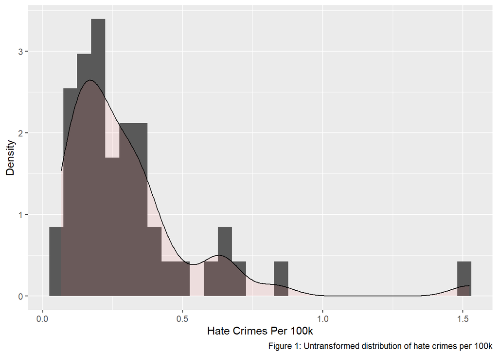

```r
hate_crimes_df %>%
  ggplot(aes(x = hate_crimes_per_100k_splc)) +
  geom_histogram(aes(y=..density..)) +
  geom_density(alpha=.1, fill="#FF6666") +
  labs(
    x = "Hate Crimes Per 100k",
    y = "Density",
    caption = "Figure 1: Untransformed distribution of hate crimes per 100k"
  )
```

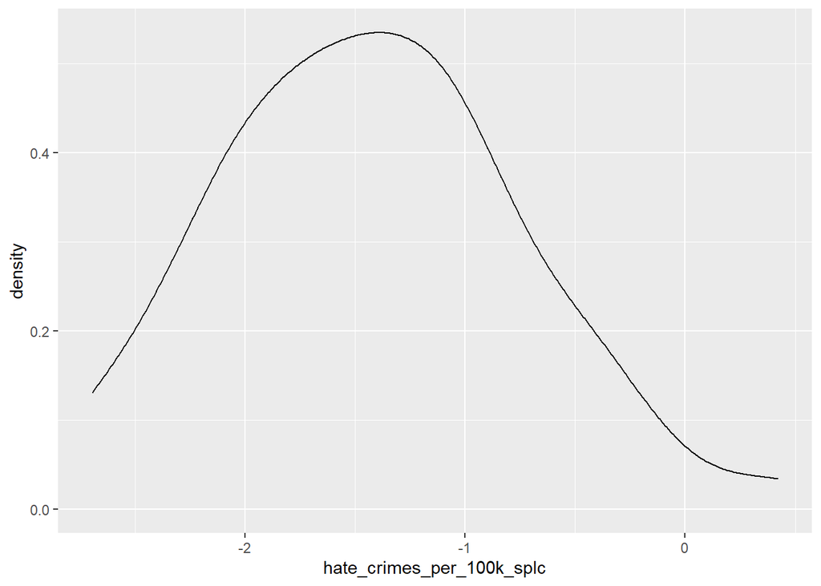

```r
hate_crimes_df %>%
  mutate(hate_crimes_per_100k_splc = log(hate_crimes_per_100k_splc)) %>%
  ggplot(aes(x = hate_crimes_per_100k_splc)) +
  geom_density()
```

```r
hate_crimes_df <- hate_crimes_df %>%
  mutate(hate_crimes_log = log(hate_crimes_per_100k_splc))
```

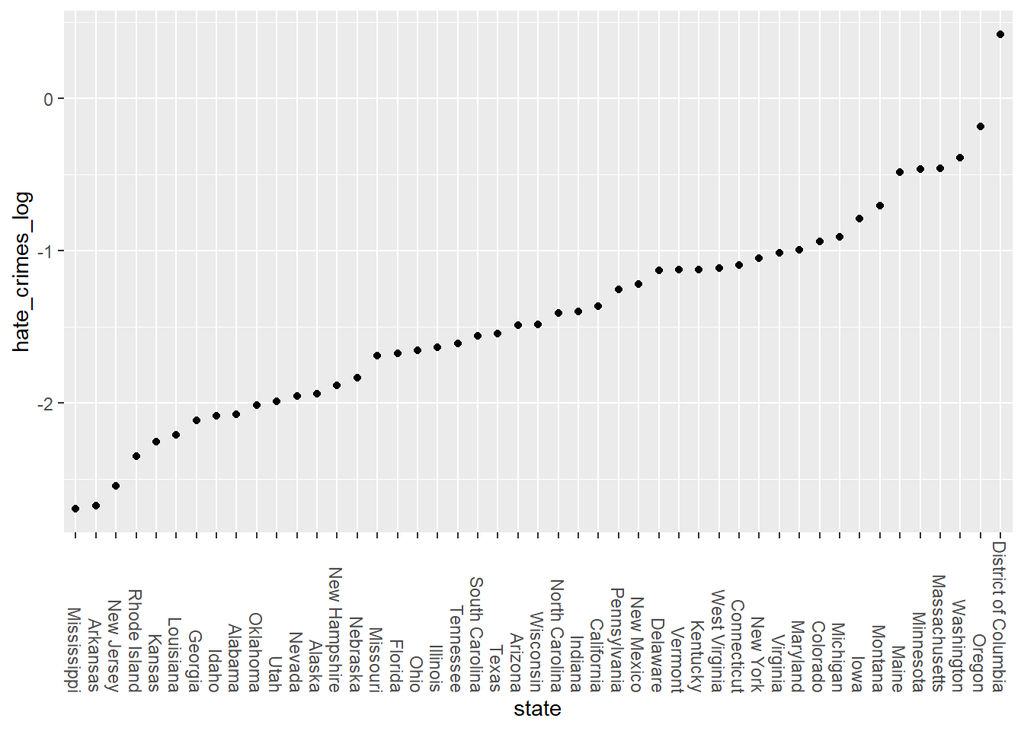

```r
hate_crimes_df %>%
  mutate(state = fct_reorder(state, hate_crimes_log)) %>%
ggplot(aes(x = state, y = hate_crimes_log)) +
  geom_point() +
  theme(axis.text.x = element_text(angle = 270, vjust = 0.5, hjust=1))
```

DESCRIPTIVE STATISTICS Table 1 More boxplots etc. Box Cox 2 people:Stella, Vasili

Regress given covariate (original model given by article)

```r
summary(lm(hate_crimes_per_100k_splc ~ . - state - hate_crimes_log, data = hate_crimes_df))
```

```
##
## Call:
## lm(formula = hate_crimes_per_100k_splc ~ . - state - hate_crimes_log,
##     data = hate_crimes_df)
##
## Residuals:
##      Min       1Q   Median       3Q      Max
## -0.36552 -0.10314 -0.01316  0.09731  0.51389
##
## Coefficients:
##                           Estimate Std. Error t value Pr(>|t|)
## (Intercept)             -8.263e+00  1.897e+00  -4.356 0.000101 ***
## unemploymentlow          1.307e-02  7.173e-02   0.182 0.856425
## urbanizationhigh        -3.309e-02  8.475e-02  -0.390 0.698475
## median_household_income -1.504e-06  5.961e-06  -0.252 0.802193
## perc_pop_hs              5.382e+00  1.835e+00   2.933 0.005735 **
## perc_non_citizen         1.233e+00  1.877e+00   0.657 0.515332
## gini_index               8.624e+00  1.973e+00   4.370 9.67e-05 ***
## perc_non_white          -5.842e-03  3.673e-01  -0.016 0.987396
## ---
## Signif. codes:  0 '***' 0.001 '**' 0.01 '*' 0.05 '.' 0.1 ' ' 1
##
## Residual standard error: 0.2014 on 37 degrees of freedom
##   (2 observations deleted due to missingness)
## Multiple R-squared:  0.461,  Adjusted R-squared:  0.3591
## F-statistic: 4.521 on 7 and 37 DF,  p-value: 0.001007
```

Yes, it does seem that the Gini index (income inequality) is the most significant predictor of hate crime and percent population with a HS degree is the only other significant predictor. Both of these results agree with the article.

```r
summary(lm(hate_crimes_log ~ . - state - hate_crimes_per_100k_splc, data = hate_crimes_df))
```

```
##
## Call:
## lm(formula = hate_crimes_log ~ . - state - hate_crimes_per_100k_splc,
##     data = hate_crimes_df)
##
## Residuals:
##      Min       1Q   Median       3Q      Max
## -1.28845 -0.41144  0.01898  0.31334  1.13022
##
## Coefficients:
##                           Estimate Std. Error t value Pr(>|t|)
## (Intercept)             -1.867e+01  5.521e+00  -3.381  0.00171 **
## unemploymentlow          2.179e-01  2.088e-01   1.043  0.30353
## urbanizationhigh         9.885e-02  2.467e-01   0.401  0.69092
## median_household_income -4.732e-06  1.735e-05  -0.273  0.78658
## perc_pop_hs              1.121e+01  5.341e+00   2.098  0.04275 *
## perc_non_citizen         1.168e+00  5.464e+00   0.214  0.83189
## gini_index               1.670e+01  5.744e+00   2.908  0.00611 **
## perc_non_white          -1.232e-01  1.069e+00  -0.115  0.90887
## ---
## Signif. codes:  0 '***' 0.001 '**' 0.01 '*' 0.05 '.' 0.1 ' ' 1
##
## Residual standard error: 0.5862 on 37 degrees of freedom
##   (2 observations deleted due to missingness)
## Multiple R-squared:  0.3146, Adjusted R-squared:  0.1849
## F-statistic: 2.426 on 7 and 37 DF,  p-value: 0.03768
```

Here we re-ran the same model, but using log of the output. We obtain the same results in terms of sigificant variables.

### Put modeling results for just gini index as variable and log hate crimes as outcome

Lets do research to pick other covariates to include in our model

Variables shown to be statistically significant in existent literature:

- Race, religion, sexual orientation - Source: Study of Literature And Legislation on Hate Crime in America (147 page report for the US Justice Department) (https://www.ncjrs.gov/pdffiles1/nij/grants/210300.pdf)
- Urbanization/population density, economic considerations (median income, poverty level, job availability), cultural and education factors - Source: US FBI website (https://ucr.fbi.gov/hate-crime/2011/resources/variables-affecting-crime)

Can also do a backwards stepwise selection to come up with a preliminary model and then add/subtract from that too

```r
hate_crimes_df = hate_crimes_df %>%
  drop_na()

# backwards selection

mult.fit <- lm(hate_crimes_log ~ . - state - hate_crimes_per_100k_splc, data = hate_crimes_df)
step(mult.fit, direction = 'backward')
```

```
## Start:  AIC=-40.88
## hate_crimes_log ~ (state + unemployment + urbanization + median_household_income +
##     perc_pop_hs + perc_non_citizen + gini_index + perc_non_white +
##     hate_crimes_per_100k_splc) - state - hate_crimes_per_100k_splc
##
##                           Df Sum of Sq    RSS     AIC
## - perc_non_white           1   0.00456 12.719 -42.859
## - perc_non_citizen         1   0.01570 12.730 -42.820
## - median_household_income  1   0.02556 12.740 -42.785
## - urbanization             1   0.05519 12.770 -42.680
## - unemployment             1   0.37413 13.089 -41.570
## <none>                                 12.715 -40.875
## - perc_pop_hs              1   1.51318 14.228 -37.815
## - gini_index               1   2.90660 15.621 -33.611
##
## Step:  AIC=-42.86
## hate_crimes_log ~ unemployment + urbanization + median_household_income +
##     perc_pop_hs + perc_non_citizen + gini_index
##
##                           Df Sum of Sq    RSS     AIC
## - perc_non_citizen         1   0.01114 12.730 -44.820
## - median_household_income  1   0.02946 12.749 -44.755
## - urbanization             1   0.05718 12.777 -44.657
## - unemployment             1   0.41699 13.136 -43.408
## <none>                                 12.719 -42.859
## - perc_pop_hs              1   1.73309 14.452 -39.111
## - gini_index               1   2.90620 15.626 -35.599
##
## Step:  AIC=-44.82
## hate_crimes_log ~ unemployment + urbanization + median_household_income +
##     perc_pop_hs + gini_index
##
##                           Df Sum of Sq    RSS     AIC
## - median_household_income  1   0.01910 12.750 -46.752
## - urbanization             1   0.11092 12.841 -46.429
## - unemployment             1   0.41466 13.145 -45.377
## <none>                                 12.730 -44.820
## - perc_pop_hs              1   1.92883 14.659 -40.471
## - gini_index               1   3.00737 15.738 -37.277
##
```

[output cut: 12 more lines]

```
## hate_crimes_log ~ unemployment + perc_pop_hs + gini_index
##
##                Df Sum of Sq    RSS     AIC
## - unemployment  1    0.3655 13.207 -49.166
## <none>                      12.841 -48.429
## - perc_pop_hs   1    3.3459 16.187 -40.010
## - gini_index    1    4.0555 16.897 -38.079
##
## Step:  AIC=-49.17
## hate_crimes_log ~ perc_pop_hs + gini_index
##
##               Df Sum of Sq    RSS     AIC
## <none>                     13.207 -49.166
## - gini_index   1    3.7171 16.924 -40.007
## - perc_pop_hs  1    4.4569 17.664 -38.081
```

```
##
## Call:
## lm(formula = hate_crimes_log ~ perc_pop_hs + gini_index, data = hate_crimes_df)
##
## Coefficients:
## (Intercept)  perc_pop_hs   gini_index
##      -18.95        11.55        16.49
```

```r
## backwards selection found only gini index and hs education to be significant
bw_mod = lm(formula = hate_crimes_log ~ perc_pop_hs + gini_index,
    data = hate_crimes_df)
summary(bw_mod)
```

```
##
## Call:
## lm(formula = hate_crimes_log ~ perc_pop_hs + gini_index, data = hate_crimes_df)
##
## Residuals:
##      Min       1Q   Median       3Q      Max
## -1.34787 -0.39659 -0.00387  0.44892  1.06723
##
## Coefficients:
##             Estimate Std. Error t value Pr(>|t|)
## (Intercept)  -18.947      4.254  -4.454 6.14e-05 ***
## perc_pop_hs   11.554      3.069   3.765 0.000512 ***
## gini_index    16.486      4.795   3.438 0.001334 **
## ---
## Signif. codes:  0 '***' 0.001 '**' 0.01 '*' 0.05 '.' 0.1 ' ' 1
##
## Residual standard error: 0.5608 on 42 degrees of freedom
## Multiple R-squared:  0.288,  Adjusted R-squared:  0.2541
## F-statistic: 8.496 on 2 and 42 DF,  p-value: 0.0007974
```

```r
##backwards selection pre-excluding pop hs...does it include median income???
mult.fit.2 <- lm(hate_crimes_log ~ . - state - hate_crimes_per_100k_splc -perc_pop_hs, data = hate_crimes_df)
step(mult.fit.2, direction = 'backward')
```

```
## Start:  AIC=-37.82
## hate_crimes_log ~ (state + unemployment + urbanization + median_household_income +
##     perc_pop_hs + perc_non_citizen + gini_index + perc_non_white +
##     hate_crimes_per_100k_splc) - state - hate_crimes_per_100k_splc -
##     perc_pop_hs
##
##                           Df Sum of Sq    RSS     AIC
## - perc_non_citizen         1   0.00320 14.231 -39.805
## - urbanization             1   0.06562 14.294 -39.608
## - perc_non_white           1   0.22447 14.452 -39.111
## - unemployment             1   0.49257 14.720 -38.284
## <none>                                 14.228 -37.815
## - median_household_income  1   1.27013 15.498 -35.968
## - gini_index               1   1.93601 16.164 -34.074
##
## Step:  AIC=-39.81
## hate_crimes_log ~ unemployment + urbanization + median_household_income +
##     gini_index + perc_non_white
##
##                           Df Sum of Sq    RSS     AIC
## - urbanization             1   0.06640 14.298 -41.596
## - perc_non_white           1   0.42815 14.659 -40.471
## - unemployment             1   0.48964 14.721 -40.283
## <none>                                 14.231 -39.805
## - median_household_income  1   1.35829 15.589 -37.703
## - gini_index               1   1.94587 16.177 -36.038
##
## Step:  AIC=-41.6
## hate_crimes_log ~ unemployment + median_household_income + gini_index +
##     perc_non_white
##
##                           Df Sum of Sq    RSS     AIC
## - perc_non_white           1   0.36554 14.663 -42.460
## - unemployment             1   0.46398 14.762 -42.159
## <none>                                 14.298 -41.596
## - median_household_income  1   1.77453 16.072 -38.331
## - gini_index               1   2.28905 16.587 -36.913
##
## Step:  AIC=-42.46
## hate_crimes_log ~ unemployment + median_household_income + gini_index
##
##                           Df Sum of Sq    RSS     AIC
## <none>                                 14.663 -42.460
## - unemployment             1   0.82946 15.493 -41.984
## - median_household_income  1   1.52421 16.187 -40.010
## - gini_index               1   1.93578 16.599 -38.880
```

```
##
## Call:
## lm(formula = hate_crimes_log ~ unemployment + median_household_income +
##     gini_index, data = hate_crimes_df)
##
## Coefficients:
##             (Intercept)          unemploymentlow  median_household_income
##              -7.770e+00                3.052e-01                2.144e-05
##              gini_index
##               1.100e+01
```

```r
bw_mod_no_hs = lm(formula = hate_crimes_log ~ median_household_income + gini_index,
    data = hate_crimes_df)
summary(bw_mod_no_hs)
```

```
##
## Call:
## lm(formula = hate_crimes_log ~ median_household_income + gini_index,
##     data = hate_crimes_df)
##
## Residuals:
##     Min      1Q  Median      3Q     Max
## -1.4414 -0.3750  0.0119  0.3473  1.2044
##
## Coefficients:
##                           Estimate Std. Error t value Pr(>|t|)
## (Intercept)             -6.528e+00  2.163e+00  -3.017  0.00432 **
## median_household_income  2.495e-05  1.028e-05   2.426  0.01963 *
## gini_index               8.177e+00  4.418e+00   1.851  0.07121 .
## ---
## Signif. codes:  0 '***' 0.001 '**' 0.01 '*' 0.05 '.' 0.1 ' ' 1
##
## Residual standard error: 0.6073 on 42 degrees of freedom
## Multiple R-squared:  0.1648, Adjusted R-squared:  0.125
## F-statistic: 4.144 on 2 and 42 DF,  p-value: 0.02277
```

```r
summary(lm(formula = hate_crimes_log ~ median_household_income +perc_pop_hs + gini_index,
    data = hate_crimes_df))
```

```
##
## Call:
## lm(formula = hate_crimes_log ~ median_household_income + perc_pop_hs +
##     gini_index, data = hate_crimes_df)
##
## Residuals:
##      Min       1Q   Median       3Q      Max
## -1.34918 -0.39571 -0.00371  0.44992  1.06741
##
## Coefficients:
##                           Estimate Std. Error t value Pr(>|t|)
## (Intercept)             -1.891e+01  5.069e+00  -3.731  0.00058 ***
## median_household_income  1.824e-07  1.337e-05   0.014  0.98918
## perc_pop_hs              1.151e+01  4.322e+00   2.664  0.01099 *
## gini_index               1.646e+01  5.169e+00   3.185  0.00277 **
## ---
## Signif. codes:  0 '***' 0.001 '**' 0.01 '*' 0.05 '.' 0.1 ' ' 1
##
## Residual standard error: 0.5676 on 41 degrees of freedom
## Multiple R-squared:  0.288,  Adjusted R-squared:  0.2359
## F-statistic: 5.529 on 3 and 41 DF,  p-value: 0.002782
```

```r
# forward selection

mult.fit <- lm(hate_crimes_log ~ . - state - hate_crimes_per_100k_splc, data = hate_crimes_df)
step(mult.fit, direction = 'forward')
```

```
## Start:  AIC=-40.88
## hate_crimes_log ~ (state + unemployment + urbanization + median_household_income +
##     perc_pop_hs + perc_non_citizen + gini_index + perc_non_white +
##     hate_crimes_per_100k_splc) - state - hate_crimes_per_100k_splc
```

```
##
## Call:
## lm(formula = hate_crimes_log ~ (state + unemployment + urbanization +
##     median_household_income + perc_pop_hs + perc_non_citizen +
##     gini_index + perc_non_white + hate_crimes_per_100k_splc) -
##     state - hate_crimes_per_100k_splc, data = hate_crimes_df)
##
## Coefficients:
##             (Intercept)          unemploymentlow         urbanizationhigh
##              -1.867e+01                2.179e-01                9.885e-02
## median_household_income              perc_pop_hs         perc_non_citizen
##              -4.732e-06                1.121e+01                1.168e+00
##              gini_index           perc_non_white
##               1.670e+01               -1.232e-01
```

```r
## forward selection found urbanization, unemployment, income, percent hs education, percent non-citizen, percent non-white and gini index to be significant
fw_mod = lm(formula = hate_crimes_log ~ perc_pop_hs + gini_index + unemployment + urbanization + median_household_income + perc_non_citizen + perc_non_white, data = hate_crimes_df)
summary(fw_mod)
```

```
##
## Call:
## lm(formula = hate_crimes_log ~ perc_pop_hs + gini_index + unemployment +
##     urbanization + median_household_income + perc_non_citizen +
##     perc_non_white, data = hate_crimes_df)
##
## Residuals:
##      Min       1Q   Median       3Q      Max
## -1.28845 -0.41144  0.01898  0.31334  1.13022
##
## Coefficients:
##                           Estimate Std. Error t value Pr(>|t|)
## (Intercept)             -1.867e+01  5.521e+00  -3.381  0.00171 **
## perc_pop_hs              1.121e+01  5.341e+00   2.098  0.04275 *
## gini_index               1.670e+01  5.744e+00   2.908  0.00611 **
## unemploymentlow          2.179e-01  2.088e-01   1.043  0.30353
## urbanizationhigh         9.885e-02  2.467e-01   0.401  0.69092
## median_household_income -4.732e-06  1.735e-05  -0.273  0.78658
## perc_non_citizen         1.168e+00  5.464e+00   0.214  0.83189
## perc_non_white          -1.232e-01  1.069e+00  -0.115  0.90887
## ---
## Signif. codes:  0 '***' 0.001 '**' 0.01 '*' 0.05 '.' 0.1 ' ' 1
##
## Residual standard error: 0.5862 on 37 degrees of freedom
## Multiple R-squared:  0.3146, Adjusted R-squared:  0.1849
## F-statistic: 2.426 on 7 and 37 DF,  p-value: 0.03768
```

```r
perc_race1 = lm(formula = hate_crimes_log ~ perc_pop_hs + gini_index + perc_non_white + perc_non_citizen,
    data = hate_crimes_df)
summary(perc_race1)
```

```
##
## Call:
## lm(formula = hate_crimes_log ~ perc_pop_hs + gini_index + perc_non_white +
##     perc_non_citizen, data = hate_crimes_df)
##
## Residuals:
##      Min       1Q   Median       3Q      Max
## -1.40948 -0.41066  0.01744  0.43859  1.02151
##
## Coefficients:
##                  Estimate Std. Error t value Pr(>|t|)
## (Intercept)      -18.3088     4.5258  -4.045 0.000232 ***
## perc_pop_hs       11.0341     3.3858   3.259 0.002286 **
## gini_index        16.0974     5.4294   2.965 0.005085 **
## perc_non_white    -0.4134     1.0069  -0.411 0.683563
## perc_non_citizen   2.1824     4.3791   0.498 0.620957
## ---
## Signif. codes:  0 '***' 0.001 '**' 0.01 '*' 0.05 '.' 0.1 ' ' 1
##
## Residual standard error: 0.5728 on 40 degrees of freedom
## Multiple R-squared:  0.2926, Adjusted R-squared:  0.2218
## F-statistic: 4.136 on 4 and 40 DF,  p-value: 0.006753
```

```r
perc_race2 = lm(formula = hate_crimes_log ~ perc_pop_hs + gini_index + perc_non_citizen,
    data = hate_crimes_df)
summary(perc_race2)
```

```
##
## Call:
## lm(formula = hate_crimes_log ~ perc_pop_hs + gini_index + perc_non_citizen,
##     data = hate_crimes_df)
##
## Residuals:
##      Min       1Q   Median       3Q      Max
## -1.39344 -0.40687  0.02081  0.44697  1.04895
##
## Coefficients:
##                  Estimate Std. Error t value Pr(>|t|)
## (Intercept)      -18.7002     4.3792  -4.270 0.000113 ***
## perc_pop_hs       11.5595     3.1028   3.725 0.000588 ***
## gini_index        15.8207     5.3325   2.967 0.005002 **
## perc_non_citizen   0.9339     3.1193   0.299 0.766143
## ---
## Signif. codes:  0 '***' 0.001 '**' 0.01 '*' 0.05 '.' 0.1 ' ' 1
##
## Residual standard error: 0.5669 on 41 degrees of freedom
## Multiple R-squared:  0.2896, Adjusted R-squared:  0.2376
## F-statistic: 5.571 on 3 and 41 DF,  p-value: 0.002667
```

```r
perc_race3 = lm(formula = hate_crimes_log ~ perc_pop_hs + gini_index + perc_non_white,
    data = hate_crimes_df)
summary(perc_race3)
```

```
##
## Call:
## lm(formula = hate_crimes_log ~ perc_pop_hs + gini_index + perc_non_white,
##     data = hate_crimes_df)
##
## Residuals:
##      Min       1Q   Median       3Q      Max
## -1.34082 -0.39772 -0.00287  0.44731  1.06676
##
## Coefficients:
##                Estimate Std. Error t value Pr(>|t|)
## (Intercept)    -18.9372     4.3066  -4.397  7.6e-05 ***
## perc_pop_hs     11.4703     3.2406   3.539  0.00101 **
## gini_index      16.6691     5.2580   3.170  0.00288 **
## perc_non_white  -0.0650     0.7179  -0.091  0.92830
## ---
## Signif. codes:  0 '***' 0.001 '**' 0.01 '*' 0.05 '.' 0.1 ' ' 1
##
## Residual standard error: 0.5675 on 41 degrees of freedom
## Multiple R-squared:  0.2882, Adjusted R-squared:  0.2361
## F-statistic: 5.533 on 3 and 41 DF,  p-value: 0.002772
```

```r
# Printing the 2 best models of each size, using the Cp criterion:
hc = hate_crimes_df %>%
  drop_na() %>%
  dplyr::select(-hate_crimes_per_100k_splc, -state) %>%
  mutate(unemployment = as.numeric(unemployment),
         urbanization = as.numeric(urbanization))

leaps::leaps(x = hc[,1:7], y = hc[,8], nbest=2, method="Cp")
```

```
## $which
##       1     2     3     4     5     6     7
## 1 FALSE FALSE  TRUE FALSE FALSE FALSE FALSE
## 1 FALSE FALSE FALSE  TRUE FALSE FALSE FALSE
## 2 FALSE FALSE FALSE  TRUE FALSE  TRUE FALSE
## 2 FALSE FALSE  TRUE FALSE FALSE  TRUE FALSE
## 3  TRUE FALSE FALSE  TRUE FALSE  TRUE FALSE
## 3 FALSE  TRUE FALSE  TRUE FALSE  TRUE FALSE
## 4  TRUE  TRUE FALSE  TRUE FALSE  TRUE FALSE
## 4  TRUE FALSE FALSE  TRUE  TRUE  TRUE FALSE
## 5  TRUE  TRUE  TRUE  TRUE FALSE  TRUE FALSE
## 5  TRUE  TRUE FALSE  TRUE FALSE  TRUE  TRUE
## 6  TRUE  TRUE  TRUE  TRUE  TRUE  TRUE FALSE
## 6  TRUE  TRUE  TRUE  TRUE FALSE  TRUE  TRUE
## 7  TRUE  TRUE  TRUE  TRUE  TRUE  TRUE  TRUE
##
## $label
## [1] "(Intercept)" "1"           "2"           "3"           "4"
## [6] "5"           "6"           "7"
##
## $size
##  [1] 2 2 3 3 4 4 5 5 6 6 7 7 8
##
## $Cp
##  [1]  7.7611857  8.2488911 -0.5678985  6.0833538  0.3685058  1.2776033
##  [7]  2.1012737  2.2470763  4.0457027  4.0927359  6.0132813  6.0457010
## [13]  8.0000000
```

```r
# Printing the 2 best models of each size, using the adjusted R squared criterion:

leaps::leaps(x = hc[,1:7], y = hc[,8], nbest=2, method="adjr2")
```

```
## $which
##       1     2     3     4     5     6     7
## 1 FALSE FALSE  TRUE FALSE FALSE FALSE FALSE
## 1 FALSE FALSE FALSE  TRUE FALSE FALSE FALSE
## 2 FALSE FALSE FALSE  TRUE FALSE  TRUE FALSE
## 2 FALSE FALSE  TRUE FALSE FALSE  TRUE FALSE
## 3  TRUE FALSE FALSE  TRUE FALSE  TRUE FALSE
## 3 FALSE  TRUE FALSE  TRUE FALSE  TRUE FALSE
## 4  TRUE  TRUE FALSE  TRUE FALSE  TRUE FALSE
## 4  TRUE FALSE FALSE  TRUE  TRUE  TRUE FALSE
## 5  TRUE  TRUE  TRUE  TRUE FALSE  TRUE FALSE
## 5  TRUE  TRUE FALSE  TRUE FALSE  TRUE  TRUE
## 6  TRUE  TRUE  TRUE  TRUE  TRUE  TRUE FALSE
## 6  TRUE  TRUE  TRUE  TRUE FALSE  TRUE  TRUE
## 7  TRUE  TRUE  TRUE  TRUE  TRUE  TRUE  TRUE
##
## $label
## [1] "(Intercept)" "1"           "2"           "3"           "4"
## [6] "5"           "6"           "7"
##
## $size
##  [1] 2 2 3 3 4 4 5 5 6 6 7 7 8
##
## $adjr2
##  [1] 0.07567476 0.06642974 0.25412878 0.12504456 0.25708199 0.23900835
##  [7] 0.24395467 0.24098352 0.22573035 0.22474733 0.20605028 0.20535487
## [13] 0.18488477
```

```r
b <- regsubsets(hate_crimes_log ~ ., data=hc)
rs <- summary(b)
rs
```

```
## Subset selection object
## Call: regsubsets.formula(hate_crimes_log ~ ., data = hc)
## 7 Variables  (and intercept)
##                         Forced in Forced out
## unemployment                FALSE      FALSE
## urbanization                FALSE      FALSE
## median_household_income     FALSE      FALSE
## perc_pop_hs                 FALSE      FALSE
## perc_non_citizen            FALSE      FALSE
## gini_index                  FALSE      FALSE
## perc_non_white              FALSE      FALSE
## 1 subsets of each size up to 7
## Selection Algorithm: exhaustive
##          unemployment urbanization median_household_income perc_pop_hs
## 1  ( 1 ) " "          " "          "*"                     " "
## 2  ( 1 ) " "          " "          " "                     "*"
## 3  ( 1 ) "*"          " "          " "                     "*"
## 4  ( 1 ) "*"          "*"          " "                     "*"
## 5  ( 1 ) "*"          "*"          "*"                     "*"
## 6  ( 1 ) "*"          "*"          "*"                     "*"
## 7  ( 1 ) "*"          "*"          "*"                     "*"
##          perc_non_citizen gini_index perc_non_white
## 1  ( 1 ) " "              " "        " "
## 2  ( 1 ) " "              "*"        " "
## 3  ( 1 ) " "              "*"        " "
## 4  ( 1 ) " "              "*"        " "
## 5  ( 1 ) " "              "*"        " "
## 6  ( 1 ) "*"              "*"        " "
## 7  ( 1 ) "*"              "*"        "*"
```

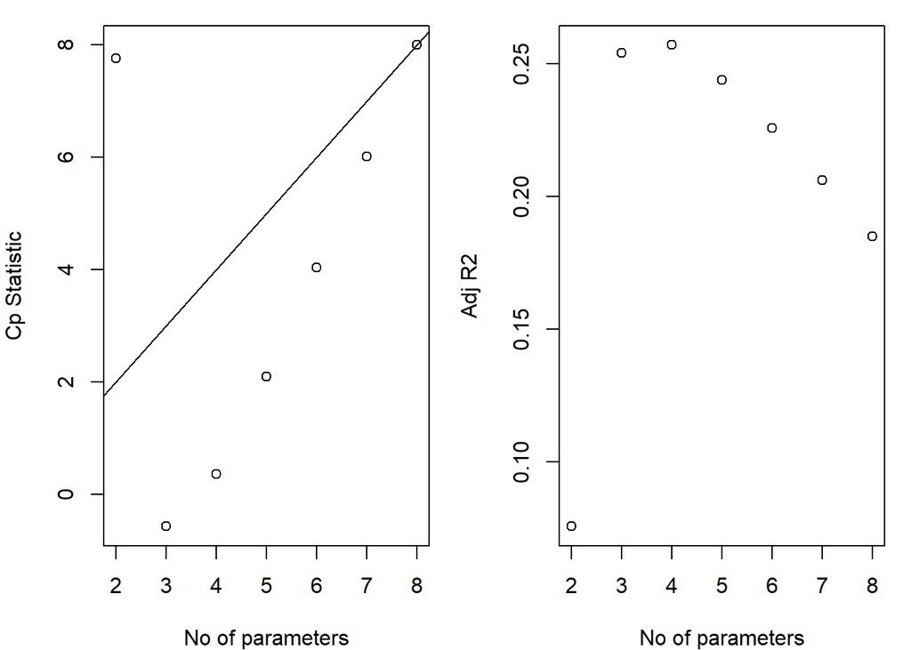

```r
par(mar=c(4,4,1,1))
par(mfrow=c(1,2))

plot(2:8, rs$cp, xlab="No of parameters", ylab="Cp Statistic")
abline(0,1)

plot(2:8, rs$adjr2, xlab="No of parameters", ylab="Adj R2")
```

```r
# Summary of models for each size (one model per size)
# Function regsubsets() performs a subset slection by identifying the "best" model that contains a certain number of predictors. By default "best" is chosen using SSE/RSS (smaller is better).


hc_1 = hate_crimes_df %>%
  drop_na() %>%
  dplyr::select(-hate_crimes_per_100k_splc, -state) %>%
  mutate(unemployment = as.numeric(unemployment),
         urbanization = as.numeric(urbanization))

b_1 <- leaps::regsubsets(hate_crimes_log ~ ., data=hc_1, nvmax = 7)
summary(b_1)
```

```
## Subset selection object
## Call: regsubsets.formula(hate_crimes_log ~ ., data = hc_1, nvmax = 7)
## 7 Variables  (and intercept)
##                         Forced in Forced out
## unemployment                FALSE      FALSE
## urbanization                FALSE      FALSE
## median_household_income     FALSE      FALSE
## perc_pop_hs                 FALSE      FALSE
## perc_non_citizen            FALSE      FALSE
## gini_index                  FALSE      FALSE
## perc_non_white              FALSE      FALSE
## 1 subsets of each size up to 7
## Selection Algorithm: exhaustive
##          unemployment urbanization median_household_income perc_pop_hs
## 1  ( 1 ) " "          " "          "*"                     " "
## 2  ( 1 ) " "          " "          " "                     "*"
## 3  ( 1 ) "*"          " "          " "                     "*"
## 4  ( 1 ) "*"          "*"          " "                     "*"
## 5  ( 1 ) "*"          "*"          "*"                     "*"
## 6  ( 1 ) "*"          "*"          "*"                     "*"
## 7  ( 1 ) "*"          "*"          "*"                     "*"
##          perc_non_citizen gini_index perc_non_white
## 1  ( 1 ) " "              " "        " "
## 2  ( 1 ) " "              "*"        " "
## 3  ( 1 ) " "              "*"        " "
## 4  ( 1 ) " "              "*"        " "
## 5  ( 1 ) " "              "*"        " "
## 6  ( 1 ) "*"              "*"        " "
## 7  ( 1 ) "*"              "*"        "*"
```

```r
res.sum_1 <- summary(b_1)
data.frame(
  Adj.R2 = which.max(res.sum_1$adjr2),
  CP = which.min(res.sum_1$cp),
  BIC = which.min(res.sum_1$bic)
)
```

```
##   Adj.R2 CP BIC
## 1      3  2   2
```

```r
final_model <- lm(hate_crimes_log ~ gini_index + perc_pop_hs, data = hate_crimes_df )
summary(final_model)
```

```
##
## Call:
## lm(formula = hate_crimes_log ~ gini_index + perc_pop_hs, data = hate_crimes_df)
##
## Residuals:
##      Min       1Q   Median       3Q      Max
## -1.34787 -0.39659 -0.00387  0.44892  1.06723
##
## Coefficients:
##             Estimate Std. Error t value Pr(>|t|)
## (Intercept)  -18.947      4.254  -4.454 6.14e-05 ***
## gini_index    16.486      4.795   3.438 0.001334 **
## perc_pop_hs   11.554      3.069   3.765 0.000512 ***
## ---
## Signif. codes:  0 '***' 0.001 '**' 0.01 '*' 0.05 '.' 0.1 ' ' 1
##
## Residual standard error: 0.5608 on 42 degrees of freedom
## Multiple R-squared:  0.288,  Adjusted R-squared:  0.2541
## F-statistic: 8.496 on 2 and 42 DF,  p-value: 0.0007974
```

```r
final_model_unemploy <- lm(hate_crimes_log ~ gini_index + perc_pop_hs + unemployment, data = hate_crimes_df)
summary(final_model_unemploy)
```

```
##
## Call:
## lm(formula = hate_crimes_log ~ gini_index + perc_pop_hs + unemployment,
##     data = hate_crimes_df)
##
## Residuals:
##     Min      1Q  Median      3Q     Max
## -1.2485 -0.3748  0.0442  0.3615  1.2020
##
## Coefficients:
##                 Estimate Std. Error t value Pr(>|t|)
## (Intercept)     -18.6703     4.2534  -4.390 7.79e-05 ***
## gini_index       17.6545     4.9062   3.598 0.000854 ***
## perc_pop_hs      10.5034     3.2136   3.268 0.002193 **
## unemploymentlow   0.2073     0.1919   1.080 0.286341
## ---
## Signif. codes:  0 '***' 0.001 '**' 0.01 '*' 0.05 '.' 0.1 ' ' 1
##
## Residual standard error: 0.5596 on 41 degrees of freedom
## Multiple R-squared:  0.3077, Adjusted R-squared:  0.2571
## F-statistic: 6.075 on 3 and 41 DF,  p-value: 0.001611
```

```r
anova(final_model, final_model_unemploy)
```

```
## Analysis of Variance Table
##
## Model 1: hate_crimes_log ~ gini_index + perc_pop_hs
## Model 2: hate_crimes_log ~ gini_index + perc_pop_hs + unemployment
##   Res.Df    RSS Df Sum of Sq     F Pr(>F)
## 1     42 13.207
## 2     41 12.841  1    0.3655 1.167 0.2863
```

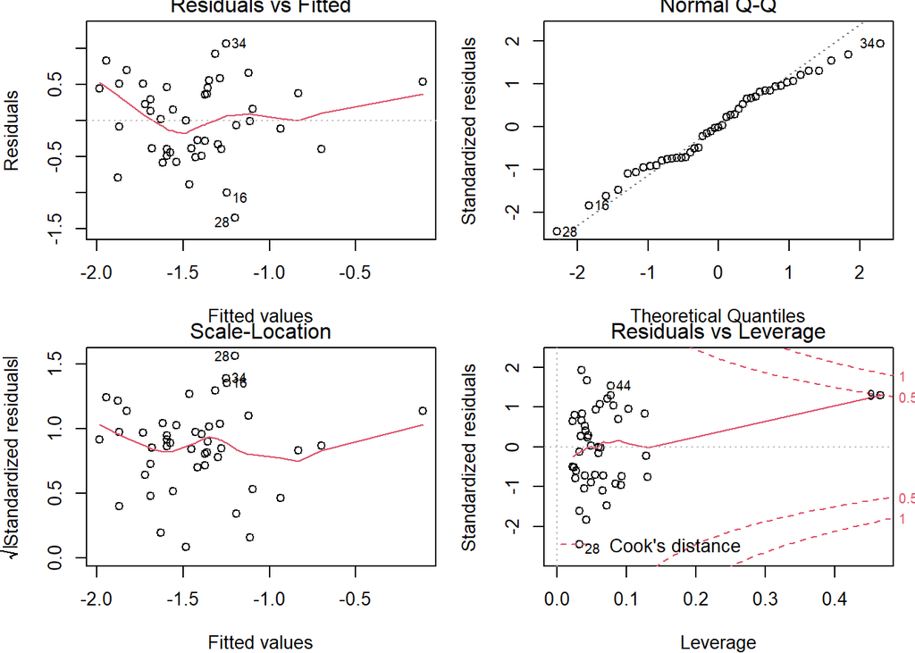

```r
par(mfrow = c(2,2))
plot(final_model)
```

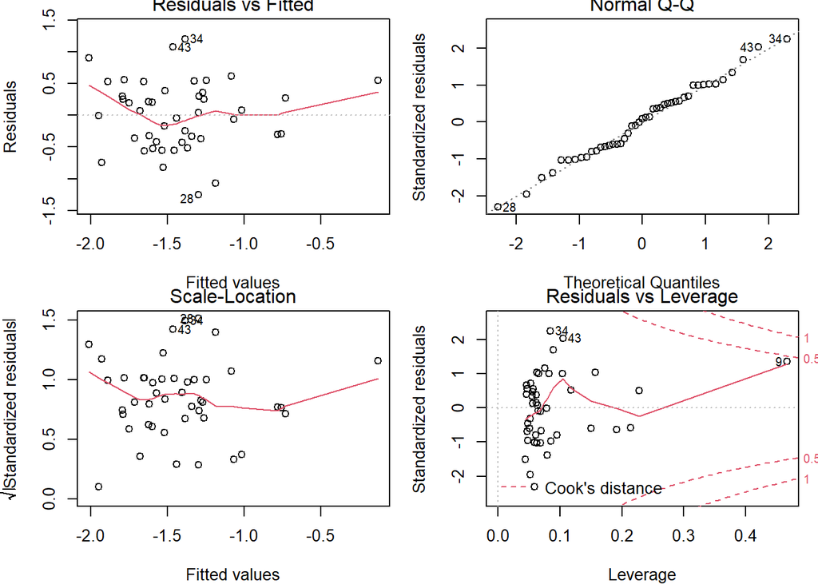

```r
plot(final_model_unemploy)
```

```r
full_mod = lm(hate_crimes_log ~ . - state - hate_crimes_per_100k_splc + unemployment*perc_pop_hs + unemployment*median_household_income + unemployment*perc_non_citizen + unemployment*gini_index + unemployment*perc_non_white + urbanization*perc_pop_hs + urbanization*median_household_income + urbanization*perc_non_citizen + urbanization*gini_index + urbanization*perc_non_white, data = hate_crimes_df)

summary(full_mod)
```

```
##
## Call:
## lm(formula = hate_crimes_log ~ . - state - hate_crimes_per_100k_splc +
##     unemployment * perc_pop_hs + unemployment * median_household_income +
##     unemployment * perc_non_citizen + unemployment * gini_index +
##     unemployment * perc_non_white + urbanization * perc_pop_hs +
##     urbanization * median_household_income + urbanization * perc_non_citizen +
##     urbanization * gini_index + urbanization * perc_non_white,
##     data = hate_crimes_df)
##
## Residuals:
##      Min       1Q   Median       3Q      Max
## -1.38885 -0.32696  0.00547  0.35682  0.99394
##
## Coefficients:
##                                            Estimate Std. Error t value Pr(>|t|)
## (Intercept)                              -2.547e+01  2.049e+01  -1.243    0.225
## unemploymentlow                           9.433e+00  1.545e+01   0.611    0.547
## urbanizationhigh                         -1.317e-02  2.008e+01  -0.001    0.999
## median_household_income                  -7.297e-05  6.099e-05  -1.196    0.242
## perc_pop_hs                               2.587e+01  1.807e+01   1.432    0.164
## perc_non_citizen                         -2.565e+00  1.680e+01  -0.153    0.880
## gini_index                                1.156e+01  2.289e+01   0.505    0.617
## perc_non_white                            6.120e-01  2.007e+00   0.305    0.763
## unemploymentlow:perc_pop_hs              -1.719e+01  1.550e+01  -1.109    0.277
## unemploymentlow:median_household_income   5.714e-05  5.523e-05   1.035    0.310
## unemploymentlow:perc_non_citizen          1.161e+00  1.717e+01   0.068    0.947
## unemploymentlow:gini_index                7.176e+00  1.738e+01   0.413    0.683
## unemploymentlow:perc_non_white           -3.014e+00  3.370e+00  -0.894    0.379
## urbanizationhigh:perc_pop_hs             -4.085e+00  1.749e+01  -0.234    0.817
## urbanizationhigh:median_household_income  5.809e-05  5.938e-05   0.978    0.337
## urbanizationhigh:perc_non_citizen         2.159e+00  1.888e+01   0.114    0.910
## urbanizationhigh:gini_index               3.000e-01  2.353e+01   0.013    0.990
## urbanizationhigh:perc_non_white           1.177e+00  3.210e+00   0.367    0.717
##
## Residual standard error: 0.636 on 27 degrees of freedom
## Multiple R-squared:  0.4112, Adjusted R-squared:  0.04042
## F-statistic: 1.109 on 17 and 27 DF,  p-value: 0.3944
```

```r
full_mod_1 = lm(hate_crimes_log ~ . - state - hate_crimes_per_100k_splc + unemployment*perc_pop_hs + unemployment*perc_non_citizen + unemployment*gini_index + unemployment*perc_non_white + urbanization*perc_pop_hs + urbanization*perc_non_citizen + urbanization*gini_index + urbanization*perc_non_white, data = hate_crimes_df)

summary(full_mod_1)
```

```
##
## Call:
## lm(formula = hate_crimes_log ~ . - state - hate_crimes_per_100k_splc +
##     unemployment * perc_pop_hs + unemployment * perc_non_citizen +
##     unemployment * gini_index + unemployment * perc_non_white +
##     urbanization * perc_pop_hs + urbanization * perc_non_citizen +
##     urbanization * gini_index + urbanization * perc_non_white,
##     data = hate_crimes_df)
##
## Residuals:
##      Min       1Q   Median       3Q      Max
## -1.41267 -0.36444  0.01033  0.34240  1.05829
##
## Coefficients:
##                                     Estimate Std. Error t value Pr(>|t|)
## (Intercept)                       -1.596e+01  1.851e+01  -0.862    0.396
## unemploymentlow                    1.423e+00  1.309e+01   0.109    0.914
## urbanizationhigh                  -8.143e+00  1.782e+01  -0.457    0.651
## median_household_income           -7.328e-06  2.051e-05  -0.357    0.724
## perc_pop_hs                        1.028e+01  1.165e+01   0.882    0.385
## perc_non_citizen                  -7.790e+00  1.597e+01  -0.488    0.629
## gini_index                         1.340e+01  2.255e+01   0.594    0.557
## perc_non_white                     1.273e-01  1.938e+00   0.066    0.948
## unemploymentlow:perc_pop_hs       -3.530e+00  8.930e+00  -0.395    0.695
## unemploymentlow:perc_non_citizen   6.581e+00  1.424e+01   0.462    0.647
## unemploymentlow:gini_index         4.417e+00  1.676e+01   0.264    0.794
## unemploymentlow:perc_non_white    -1.730e+00  2.914e+00  -0.594    0.557
## urbanizationhigh:perc_pop_hs       1.023e+01  1.065e+01   0.960    0.345
## urbanizationhigh:perc_non_citizen  5.958e+00  1.739e+01   0.343    0.734
## urbanizationhigh:gini_index       -3.299e+00  2.270e+01  -0.145    0.885
## urbanizationhigh:perc_non_white    2.227e+00  2.890e+00   0.771    0.447
##
## Residual standard error: 0.6286 on 29 degrees of freedom
## Multiple R-squared:  0.3822, Adjusted R-squared:  0.06261
## F-statistic: 1.196 on 15 and 29 DF,  p-value: 0.3283
```

```r
small_mod = lm(hate_crimes_log ~ gini_index + perc_pop_hs + gini_index*unemployment + perc_pop_hs*unemployment, data = hate_crimes_df)

summary(small_mod)
```

```
##
## Call:
## lm(formula = hate_crimes_log ~ gini_index + perc_pop_hs + gini_index *
##     unemployment + perc_pop_hs * unemployment, data = hate_crimes_df)
##
## Residuals:
##      Min       1Q   Median       3Q      Max
## -1.28401 -0.38901 -0.00049  0.35205  1.10975
##
## Coefficients:
##                             Estimate Std. Error t value Pr(>|t|)
## (Intercept)                 -19.1784     5.2027  -3.686 0.000691 ***
## gini_index                   15.7333     6.2736   2.508 0.016418 *
## perc_pop_hs                  12.1453     4.3873   2.768 0.008577 **
## unemploymentlow               0.8635     9.5272   0.091 0.928249
## gini_index:unemploymentlow    3.6362    10.8584   0.335 0.739512
## perc_pop_hs:unemploymentlow  -2.6797     6.9788  -0.384 0.703086
## ---
## Signif. codes:  0 '***' 0.001 '**' 0.01 '*' 0.05 '.' 0.1 ' ' 1
##
## Residual standard error: 0.5701 on 39 degrees of freedom
## Multiple R-squared:  0.3167, Adjusted R-squared:  0.2292
## F-statistic: 3.616 on 5 and 39 DF,  p-value: 0.008784
```

```r
small_mod_1 = lm(hate_crimes_log ~ gini_index + perc_pop_hs + gini_index*urbanization + perc_pop_hs*urbanization, data = hate_crimes_df)

summary(small_mod_1)
```

```
##
## Call:
## lm(formula = hate_crimes_log ~ gini_index + perc_pop_hs + gini_index *
##     urbanization + perc_pop_hs * urbanization, data = hate_crimes_df)
##
## Residuals:
##      Min       1Q   Median       3Q      Max
## -1.41023 -0.41010  0.06808  0.36460  0.93507
##
## Coefficients:
##                              Estimate Std. Error t value Pr(>|t|)
## (Intercept)                  -15.6142    14.0661  -1.110    0.274
## gini_index                    14.4129    17.9621   0.802    0.427
## perc_pop_hs                    8.7553     7.4428   1.176    0.247
## urbanizationhigh              -4.9500    14.9904  -0.330    0.743
## gini_index:urbanizationhigh    0.5274    18.8457   0.028    0.978
## perc_pop_hs:urbanizationhigh   5.5411     8.6012   0.644    0.523
##
## Residual standard error: 0.5737 on 39 degrees of freedom
## Multiple R-squared:  0.3079, Adjusted R-squared:  0.2192
## F-statistic:  3.47 on 5 and 39 DF,  p-value: 0.01088
```

There shows to be no significant interactions between either of the categorical variables and the continuous variables. Nor did removing median_household_income (because of multicollinearity) show any significant interactions. There also shows to be no interactions between either of the categorical variables and gini_index and perc_pop_hs in the smaller models.

```r
hate_crimes_df_no_DC <- hate_crimes_df %>%
  filter(state != "District of Columbia")

full_mod = lm(hate_crimes_log ~ . - state - hate_crimes_per_100k_splc + unemployment*perc_pop_hs + unemployment*median_household_income + unemployment*perc_non_citizen + unemployment*gini_index + unemployment*perc_non_white + urbanization*perc_pop_hs + urbanization*median_household_income + urbanization*perc_non_citizen + urbanization*gini_index + urbanization*perc_non_white, data = hate_crimes_df_no_DC)

summary(full_mod)
```

```
##
## Call:
## lm(formula = hate_crimes_log ~ . - state - hate_crimes_per_100k_splc +
##     unemployment * perc_pop_hs + unemployment * median_household_income +
##     unemployment * perc_non_citizen + unemployment * gini_index +
##     unemployment * perc_non_white + urbanization * perc_pop_hs +
##     urbanization * median_household_income + urbanization * perc_non_citizen +
##     urbanization * gini_index + urbanization * perc_non_white,
##     data = hate_crimes_df_no_DC)
##
## Residuals:
##      Min       1Q   Median       3Q      Max
## -1.11675 -0.26877  0.01295  0.30748  0.88091
##
## Coefficients:
##                                            Estimate Std. Error t value Pr(>|t|)
## (Intercept)                              -2.079e+01  1.972e+01  -1.054    0.301
## unemploymentlow                          -2.434e+00  1.602e+01  -0.152    0.880
## urbanizationhigh                          1.380e+01  2.051e+01   0.673    0.507
## median_household_income                  -8.146e-05  5.841e-05  -1.395    0.175
## perc_pop_hs                               2.596e+01  1.726e+01   1.504    0.145
## perc_non_citizen                          1.506e+00  1.619e+01   0.093    0.927
## gini_index                                2.161e+00  2.241e+01   0.096    0.924
## perc_non_white                            1.695e-01  1.931e+00   0.088    0.931
## unemploymentlow:perc_pop_hs              -1.352e+01  1.493e+01  -0.906    0.373
## unemploymentlow:median_household_income   6.238e-05  5.282e-05   1.181    0.248
## unemploymentlow:perc_non_citizen         -3.884e-01  1.641e+01  -0.024    0.981
## unemploymentlow:gini_index                2.560e+01  1.923e+01   1.332    0.194
## unemploymentlow:perc_non_white           -2.822e+00  3.220e+00  -0.876    0.389
## urbanizationhigh:perc_pop_hs             -1.472e+01  1.762e+01  -0.836    0.411
## urbanizationhigh:median_household_income  7.414e-05  5.733e-05   1.293    0.207
## urbanizationhigh:perc_non_citizen        -1.747e+00  1.815e+01  -0.096    0.924
## urbanizationhigh:gini_index              -1.027e+01  2.315e+01  -0.444    0.661
## urbanizationhigh:perc_non_white          -1.560e-01  3.145e+00  -0.050    0.961
##
## Residual standard error: 0.6074 on 26 degrees of freedom
## Multiple R-squared:  0.364,  Adjusted R-squared:  -0.05188
## F-statistic: 0.8753 on 17 and 26 DF,  p-value: 0.6049
```

```r
full_mod_1 = lm(hate_crimes_log ~ . - state - hate_crimes_per_100k_splc + unemployment*perc_pop_hs + unemployment*perc_non_citizen + unemployment*gini_index + unemployment*perc_non_white + urbanization*perc_pop_hs + urbanization*perc_non_citizen + urbanization*gini_index + urbanization*perc_non_white, data = hate_crimes_df_no_DC)

summary(full_mod_1)
```

```
##
## Call:
## lm(formula = hate_crimes_log ~ . - state - hate_crimes_per_100k_splc +
##     unemployment * perc_pop_hs + unemployment * perc_non_citizen +
##     unemployment * gini_index + unemployment * perc_non_white +
##     urbanization * perc_pop_hs + urbanization * perc_non_citizen +
##     urbanization * gini_index + urbanization * perc_non_white,
##     data = hate_crimes_df_no_DC)
##
## Residuals:
##      Min       1Q   Median       3Q      Max
## -1.15930 -0.36101  0.07483  0.26291  0.95957
##
## Coefficients:
##                                     Estimate Std. Error t value Pr(>|t|)
## (Intercept)                       -1.003e+01  1.821e+01  -0.551    0.586
## unemploymentlow                   -9.953e+00  1.423e+01  -0.700    0.490
## urbanizationhigh                   2.207e+00  1.821e+01   0.121    0.904
## median_household_income           -3.518e-06  1.994e-05  -0.176    0.861
## perc_pop_hs                        7.525e+00  1.136e+01   0.662    0.513
## perc_non_citizen                  -5.037e+00  1.552e+01  -0.325    0.748
## gini_index                         5.302e+00  2.228e+01   0.238    0.814
## perc_non_white                    -3.369e-01  1.892e+00  -0.178    0.860
## unemploymentlow:perc_pop_hs        1.219e+00  9.049e+00   0.135    0.894
## unemploymentlow:perc_non_citizen   4.627e+00  1.380e+01   0.335    0.740
## unemploymentlow:gini_index         2.021e+01  1.855e+01   1.090    0.285
## unemploymentlow:perc_non_white    -1.147e+00  2.836e+00  -0.404    0.689
## urbanizationhigh:perc_pop_hs       3.847e+00  1.093e+01   0.352    0.727
## urbanizationhigh:perc_non_citizen  4.050e+00  1.684e+01   0.241    0.812
## urbanizationhigh:gini_index       -1.277e+01  2.260e+01  -0.565    0.576
## urbanizationhigh:perc_non_white    1.014e+00  2.878e+00   0.352    0.727
##
## Residual standard error: 0.6075 on 28 degrees of freedom
## Multiple R-squared:  0.3147, Adjusted R-squared:  -0.05247
## F-statistic: 0.8571 on 15 and 28 DF,  p-value: 0.6133
```

```r
small_mod = lm(hate_crimes_log ~ gini_index + perc_pop_hs + gini_index*unemployment + perc_pop_hs*unemployment, data = hate_crimes_df_no_DC)

summary(small_mod)
```

```
##
## Call:
## lm(formula = hate_crimes_log ~ gini_index + perc_pop_hs + gini_index *
##     unemployment + perc_pop_hs * unemployment, data = hate_crimes_df_no_DC)
##
## Residuals:
##      Min       1Q   Median       3Q      Max
## -1.09805 -0.38875  0.09688  0.32555  1.12000
##
## Coefficients:
##                             Estimate Std. Error t value Pr(>|t|)
## (Intercept)                   -7.510      7.538  -0.996    0.325
## gini_index                    -1.178     10.159  -0.116    0.908
## perc_pop_hs                    7.560      4.762   1.588    0.121
## unemploymentlow              -10.805     10.751  -1.005    0.321
## gini_index:unemploymentlow    20.548     13.254   1.550    0.129
## perc_pop_hs:unemploymentlow    1.906      7.060   0.270    0.789
##
## Residual standard error: 0.5475 on 38 degrees of freedom
## Multiple R-squared:  0.2445, Adjusted R-squared:  0.1451
## F-statistic:  2.46 on 5 and 38 DF,  p-value: 0.05021
```

```r
small_mod_1 = lm(hate_crimes_log ~ gini_index + perc_pop_hs + gini_index*urbanization + perc_pop_hs*urbanization, data = hate_crimes_df_no_DC)

summary(small_mod_1)
```

```
##
## Call:
## lm(formula = hate_crimes_log ~ gini_index + perc_pop_hs + gini_index *
##     urbanization + perc_pop_hs * urbanization, data = hate_crimes_df_no_DC)
##
## Residuals:
##      Min       1Q   Median       3Q      Max
## -1.32655 -0.39628  0.08906  0.36671  0.93315
##
## Coefficients:
##                              Estimate Std. Error t value Pr(>|t|)
## (Intercept)                   -15.614     13.839  -1.128    0.266
## gini_index                     14.413     17.673   0.816    0.420
## perc_pop_hs                     8.755      7.323   1.196    0.239
## urbanizationhigh                1.247     15.307   0.081    0.935
## gini_index:urbanizationhigh    -8.120     19.404  -0.418    0.678
## perc_pop_hs:urbanizationhigh    2.946      8.635   0.341    0.735
##
## Residual standard error: 0.5645 on 38 degrees of freedom
## Multiple R-squared:  0.197,  Adjusted R-squared:  0.09134
## F-statistic: 1.864 on 5 and 38 DF,  p-value: 0.1236
```

```r
hc = hate_crimes_df_no_DC %>%
  drop_na() %>%
  dplyr::select(-hate_crimes_per_100k_splc, -state) %>%
  mutate(unemployment = as.numeric(unemployment),
         urbanization = as.numeric(urbanization))

leaps::leaps(x = hc[,1:7], y = hc[,8], nbest=2, method="Cp")
```

```
## $which
##       1     2     3     4     5     6     7
## 1 FALSE FALSE FALSE  TRUE FALSE FALSE FALSE
## 1  TRUE FALSE FALSE FALSE FALSE FALSE FALSE
## 2 FALSE FALSE FALSE  TRUE FALSE  TRUE FALSE
## 2 FALSE  TRUE FALSE  TRUE FALSE FALSE FALSE
## 3  TRUE FALSE FALSE  TRUE FALSE  TRUE FALSE
## 3 FALSE  TRUE FALSE  TRUE FALSE  TRUE FALSE
## 4  TRUE  TRUE FALSE  TRUE FALSE  TRUE FALSE
## 4  TRUE FALSE FALSE  TRUE  TRUE  TRUE FALSE
## 5  TRUE  TRUE FALSE  TRUE FALSE  TRUE  TRUE
## 5  TRUE  TRUE  TRUE  TRUE FALSE  TRUE FALSE
## 6  TRUE  TRUE  TRUE  TRUE FALSE  TRUE  TRUE
## 6  TRUE  TRUE FALSE  TRUE  TRUE  TRUE  TRUE
## 7  TRUE  TRUE  TRUE  TRUE  TRUE  TRUE  TRUE
##
## $label
## [1] "(Intercept)" "1"           "2"           "3"           "4"
## [6] "5"           "6"           "7"
##
## $size
##  [1] 2 2 3 3 4 4 5 5 6 6 7 7 8
##
## $Cp
##  [1] 0.9573036 2.5025339 0.3147492 1.2724321 1.1047095 1.8760111 2.4514214
##  [8] 2.9790001 4.1778725 4.2241098 6.0853808 6.1447649 8.0000000
```

```r
# Printing the 2 best models of each size, using the adjusted R squared criterion:

leaps::leaps(x = hc[,1:7], y = hc[,8], nbest=2, method="adjr2")
```

```
## $which
##       1     2     3     4     5     6     7
## 1 FALSE FALSE FALSE  TRUE FALSE FALSE FALSE
## 1  TRUE FALSE FALSE FALSE FALSE FALSE FALSE
## 2 FALSE FALSE FALSE  TRUE FALSE  TRUE FALSE
## 2 FALSE  TRUE FALSE  TRUE FALSE FALSE FALSE
## 3  TRUE FALSE FALSE  TRUE FALSE  TRUE FALSE
## 3 FALSE  TRUE FALSE  TRUE FALSE  TRUE FALSE
## 4  TRUE  TRUE FALSE  TRUE FALSE  TRUE FALSE
## 4  TRUE FALSE FALSE  TRUE  TRUE  TRUE FALSE
## 5  TRUE  TRUE FALSE  TRUE FALSE  TRUE  TRUE
## 5  TRUE  TRUE  TRUE  TRUE FALSE  TRUE FALSE
## 6  TRUE  TRUE  TRUE  TRUE FALSE  TRUE  TRUE
## 6  TRUE  TRUE FALSE  TRUE  TRUE  TRUE  TRUE
## 7  TRUE  TRUE  TRUE  TRUE  TRUE  TRUE  TRUE
##
## $label
## [1] "(Intercept)" "1"           "2"           "3"           "4"
## [6] "5"           "6"           "7"
##
## $size
##  [1] 2 2 3 3 4 4 5 5 6 6 7 7 8
##
## $adjr2
##  [1] 0.08009189 0.04538575 0.11845495 0.09642060 0.12495291 0.10676316
##  [7] 0.11831746 0.10555645 0.10190597 0.10075816 0.07999127 0.07847725
## [13] 0.05667275
```

```r
b <- regsubsets(hate_crimes_log ~ ., data=hc)
rs <- summary(b)
rs
```

```
## Subset selection object
## Call: regsubsets.formula(hate_crimes_log ~ ., data = hc)
## 7 Variables  (and intercept)
##                         Forced in Forced out
## unemployment                FALSE      FALSE
## urbanization                FALSE      FALSE
## median_household_income     FALSE      FALSE
## perc_pop_hs                 FALSE      FALSE
## perc_non_citizen            FALSE      FALSE
## gini_index                  FALSE      FALSE
## perc_non_white              FALSE      FALSE
## 1 subsets of each size up to 7
## Selection Algorithm: exhaustive
##          unemployment urbanization median_household_income perc_pop_hs
## 1  ( 1 ) " "          " "          " "                     "*"
## 2  ( 1 ) " "          " "          " "                     "*"
## 3  ( 1 ) "*"          " "          " "                     "*"
## 4  ( 1 ) "*"          "*"          " "                     "*"
## 5  ( 1 ) "*"          "*"          " "                     "*"
## 6  ( 1 ) "*"          "*"          "*"                     "*"
## 7  ( 1 ) "*"          "*"          "*"                     "*"
##          perc_non_citizen gini_index perc_non_white
## 1  ( 1 ) " "              " "        " "
## 2  ( 1 ) " "              "*"        " "
## 3  ( 1 ) " "              "*"        " "
## 4  ( 1 ) " "              "*"        " "
## 5  ( 1 ) " "              "*"        "*"
## 6  ( 1 ) " "              "*"        "*"
## 7  ( 1 ) "*"              "*"        "*"
```

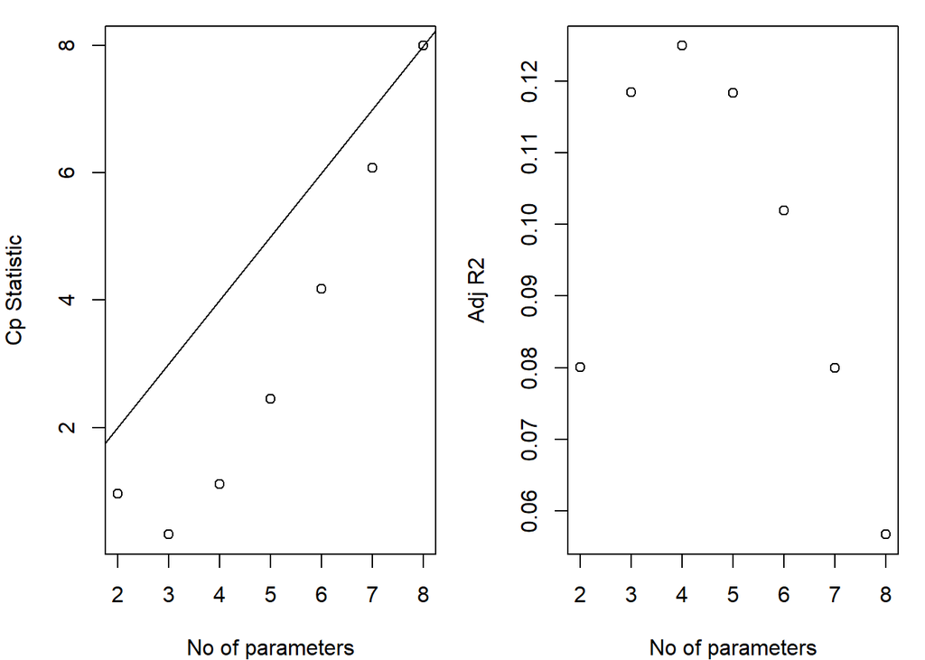

```r
par(mar=c(4,4,1,1))
par(mfrow=c(1,2))

plot(2:8, rs$cp, xlab="No of parameters", ylab="Cp Statistic")
abline(0,1)

plot(2:8, rs$adjr2, xlab="No of parameters", ylab="Adj R2")
```

```r
res.sum_1 <- summary(b_1)
data.frame(
  Adj.R2 = which.max(res.sum_1$adjr2),
  CP = which.min(res.sum_1$cp),
  BIC = which.min(res.sum_1$bic)
)
```

```
##   Adj.R2 CP BIC
## 1      3  2   2
```

```r
final_model_no_DC <- lm(hate_crimes_log ~ gini_index + perc_pop_hs, data = hate_crimes_df_no_DC )
summary(final_model_no_DC)
```

```
##
## Call:
## lm(formula = hate_crimes_log ~ gini_index + perc_pop_hs, data = hate_crimes_df_no_DC)
##
## Residuals:
##      Min       1Q   Median       3Q      Max
## -1.26341 -0.43818  0.03534  0.42669  1.10132
##
## Coefficients:
##             Estimate Std. Error t value Pr(>|t|)
## (Intercept)  -14.611      5.359  -2.726  0.00938 **
## gini_index    10.811      6.429   1.682  0.10025
## perc_pop_hs    9.509      3.419   2.781  0.00814 **
## ---
## Signif. codes:  0 '***' 0.001 '**' 0.01 '*' 0.05 '.' 0.1 ' ' 1
##
## Residual standard error: 0.556 on 41 degrees of freedom
## Multiple R-squared:  0.1595, Adjusted R-squared:  0.1185
## F-statistic: 3.889 on 2 and 41 DF,  p-value: 0.02841
```

```r
final_model_no_DC_unemploy <- lm(hate_crimes_log ~ gini_index + perc_pop_hs + unemployment, data = hate_crimes_df_no_DC)
summary(final_model_no_DC_unemploy)
```

```
##
## Call:
## lm(formula = hate_crimes_log ~ gini_index + perc_pop_hs + unemployment,
##     data = hate_crimes_df_no_DC)
##
## Residuals:
##      Min       1Q   Median       3Q      Max
## -1.15652 -0.40930  0.03789  0.33998  1.24361
##
## Coefficients:
##                 Estimate Std. Error t value Pr(>|t|)
## (Intercept)     -14.1786     5.3530  -2.649   0.0115 *
## gini_index       11.8477     6.4692   1.831   0.0745 .
## perc_pop_hs       8.3417     3.5566   2.345   0.0241 *
## unemploymentlow   0.2171     0.1901   1.142   0.2602
## ---
## Signif. codes:  0 '***' 0.001 '**' 0.01 '*' 0.05 '.' 0.1 ' ' 1
##
## Residual standard error: 0.554 on 40 degrees of freedom
## Multiple R-squared:  0.186,  Adjusted R-squared:  0.125
## F-statistic: 3.047 on 3 and 40 DF,  p-value: 0.03963
```

```r
anova(final_model_no_DC, final_model_no_DC_unemploy)
```

```
## Analysis of Variance Table
##
## Model 1: hate_crimes_log ~ gini_index + perc_pop_hs
## Model 2: hate_crimes_log ~ gini_index + perc_pop_hs + unemployment
##   Res.Df    RSS Df Sum of Sq      F Pr(>F)
## 1     41 12.675
## 2     40 12.275  1    0.4003 1.3045 0.2602
```

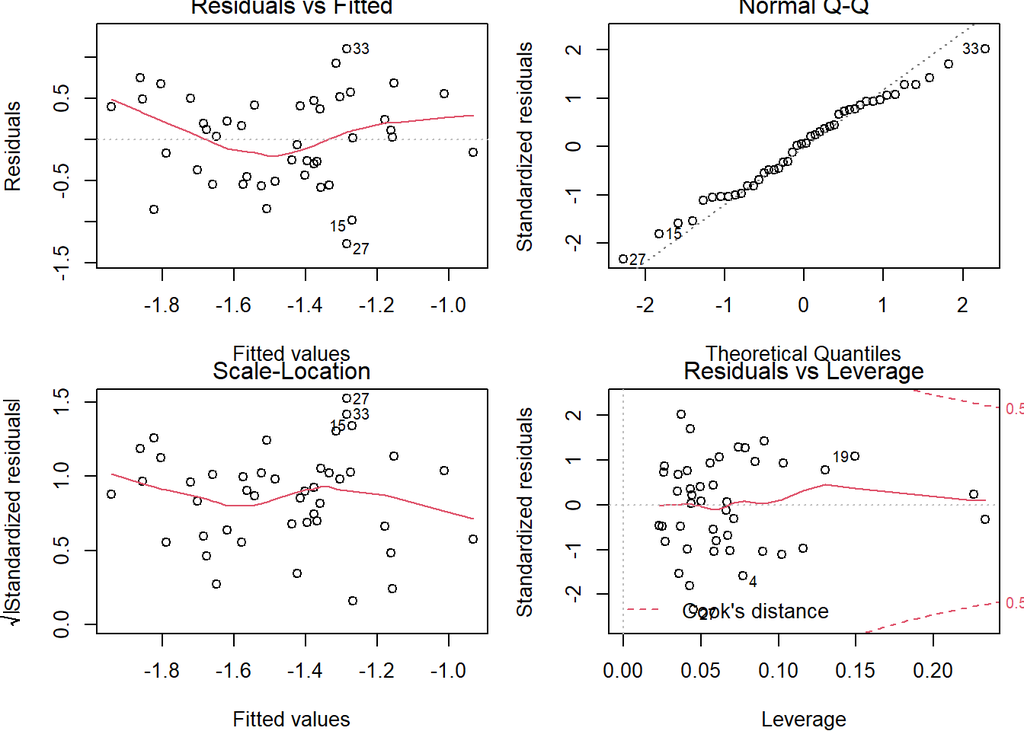

```r
par(mfrow = c(2,2))
plot(final_model_no_DC)
```

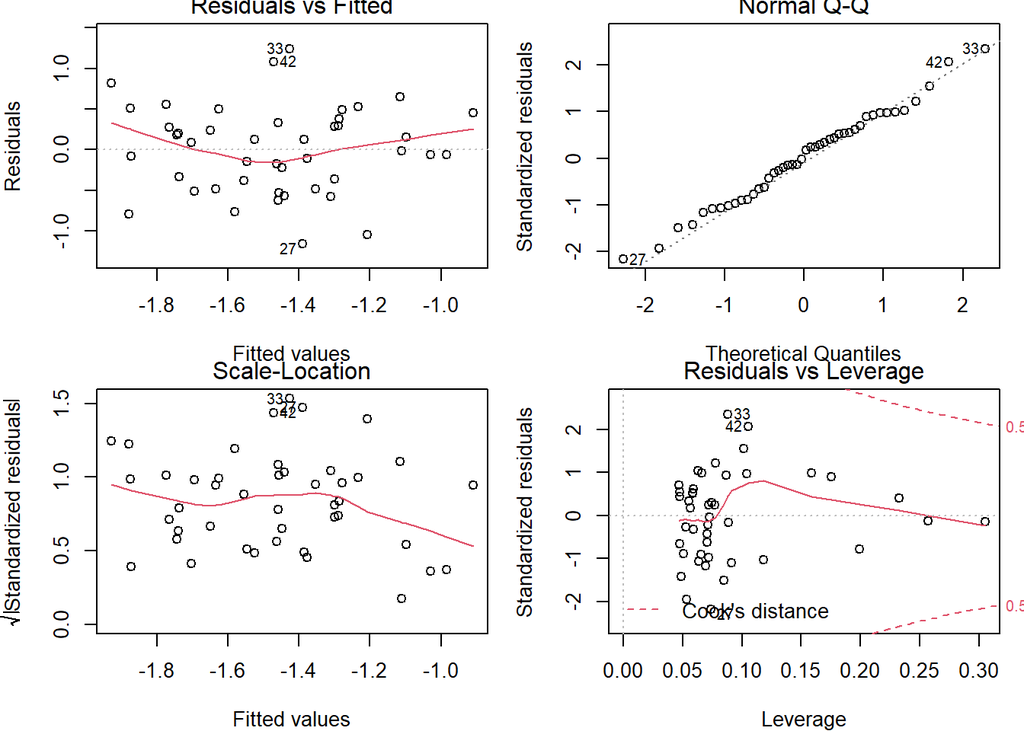

```r
plot(final_model_no_DC_unemploy)
```

Article supports percent non-white as an important variable (for college campuses): https://journals-sagepub-com.proxy.lib.umich.edu/doi/full/10.1177/1043986214536666?utm_source=summon&utm_medium=discovery-provider

Anti-hispanic and religious hate crimes on the rise: https://apnews.com/article/hate-crimes-rise-fbi-data-ebbcadca8458aba96575da905650120d

Make the association matrix and compare covariates-look for multicollinearity 3 people: Lily, Caroline, Tessa

Correlation matrix of all numeric variables with each other:

```r
hate_crimes_df %>%
  drop_na(perc_non_citizen) %>%
  dplyr::select(!(state:urbanization)) %>%
  cor() %>%
  round(.,3) %>% knitr::kable()
```

|  | median_household_income | perc_pop_hs | perc_non_citizen | gini_index | perc_non_white | hate_crimes_per_100k_splc | hate_crimes_log |
| --- | --- | --- | --- | --- | --- | --- | --- |
| median_household_income | 1.000 | 0.651 | 0.302 | -0.130 | 0.039 | 0.344 | 0.311 |
| perc_pop_hs | 0.651 | 1.000 | -0.262 | -0.537 | -0.496 | 0.263 | 0.296 |
| perc_non_citizen | 0.302 | -0.262 | 1.000 | 0.480 | 0.753 | 0.244 | 0.137 |
| gini_index | -0.130 | -0.537 | 0.480 | 1.000 | 0.548 | 0.381 | 0.219 |
| perc_non_white | 0.039 | -0.496 | 0.753 | 0.548 | 1.000 | 0.111 | -0.007 |
| hate_crimes_per_100k_splc | 0.344 | 0.263 | 0.244 | 0.381 | 0.111 | 1.000 | 0.892 |
| hate_crimes_log | 0.311 | 0.296 | 0.137 | 0.219 | -0.007 | 0.892 | 1.000 |

```r
library(car)
vif(lm(hate_crimes_log ~. - hate_crimes_per_100k_splc - state, data=hate_crimes_df)) %>%
  round(.,3) %>%
  knitr::kable()
```

|  | x |
| --- | --- |
| unemployment | 1.426 |
| urbanization | 1.983 |
| median_household_income | 3.108 |
| perc_pop_hs | 3.895 |
| perc_non_citizen | 3.728 |
| gini_index | 1.845 |
| perc_non_white | 3.236 |

Out of the continuous variables, percent non-citizen and percent non-white has a correlation coefficient of 0.753, median household income and percentage of population with a HS degree has a correlation coefficient of 0.651, both of which may suggest multi-collinearity. All other variables do not suggest multi-collinearity.

Calculate VIFs for multicollinearity

Drop either perc non citizen or per non white Drop either median household income or perc pop with HS degree-drop median household income due to multicollinearity

Test a model with interactions between each of the categorical variables and all the continuous variables-(pre-eliminate some continuous variables based on previous analysis). Interaction between each categorical variable and the perc non white and perc non citizen

Interaction graphs of unemployment with all continuous variables to help with testing interactions:

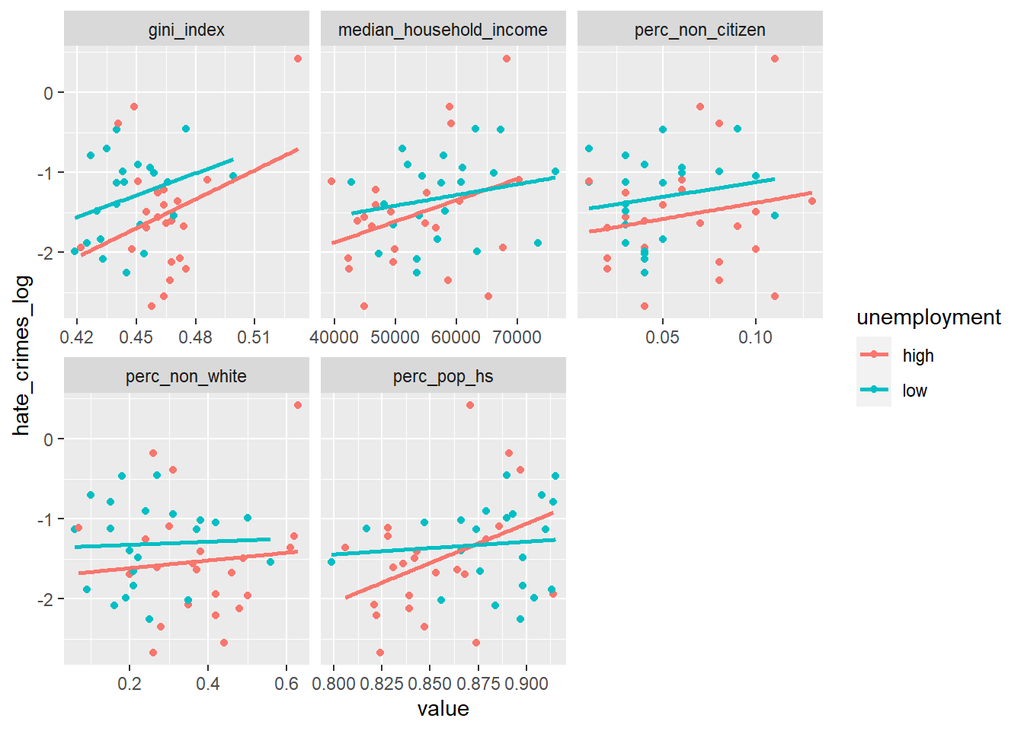

```r
hate_crimes_df %>% pivot_longer(median_household_income:perc_non_white, names_to = "cont_var", values_to = "value") %>%  ggplot(aes(x = value, y = hate_crimes_log, color = unemployment)) + geom_point() + geom_smooth(method='lm', se=FALSE) + facet_wrap(~cont_var, scales = "free_x")
```

Interaction graphs of urbanization with all continuous variables:

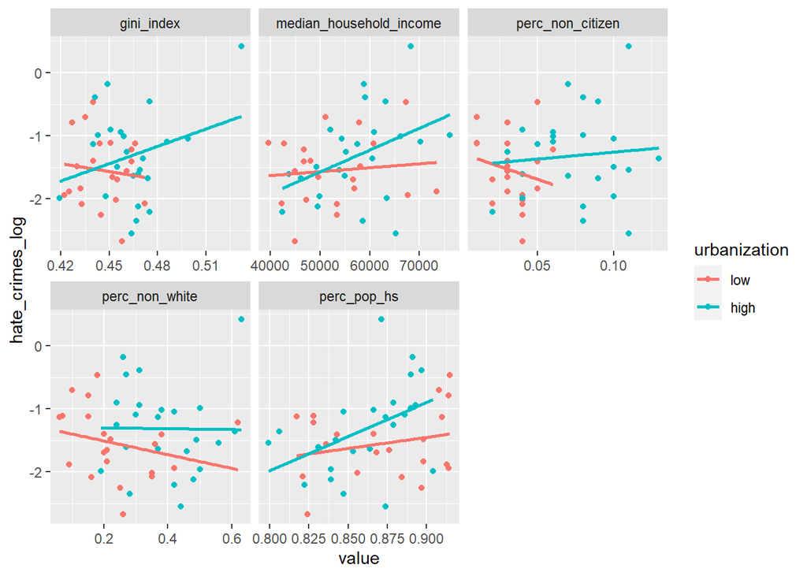

```r
hate_crimes_df %>%
  pivot_longer(median_household_income:perc_non_white, names_to = "cont_var", values_to = "value") %>%
  ggplot(aes(x = value, y = hate_crimes_log, color = urbanization)) +
  geom_point() +
  geom_smooth(method='lm', se=FALSE) +
  facet_wrap(~cont_var, scales = "free_x")
```

```r
library(caret)
final_model_no_DC <- lm(hate_crimes_log ~ gini_index + perc_pop_hs, data = hate_crimes_df_no_DC )
sm<-summary(final_model_no_DC)
sm
```

```
##
## Call:
## lm(formula = hate_crimes_log ~ gini_index + perc_pop_hs, data = hate_crimes_df_no_DC)
##
## Residuals:
##      Min       1Q   Median       3Q      Max
## -1.26341 -0.43818  0.03534  0.42669  1.10132
##
## Coefficients:
##             Estimate Std. Error t value Pr(>|t|)
## (Intercept)  -14.611      5.359  -2.726  0.00938 **
## gini_index    10.811      6.429   1.682  0.10025
## perc_pop_hs    9.509      3.419   2.781  0.00814 **
## ---
## Signif. codes:  0 '***' 0.001 '**' 0.01 '*' 0.05 '.' 0.1 ' ' 1
##
## Residual standard error: 0.556 on 41 degrees of freedom
## Multiple R-squared:  0.1595, Adjusted R-squared:  0.1185
## F-statistic: 3.889 on 2 and 41 DF,  p-value: 0.02841
```

```r
mean(sm$residuals^2)
```

```
## [1] 0.2880733
```

```r
set.seed(1)
data_train<-trainControl(method="cv", number=5)


model_caret<-train(hate_crimes_log ~ gini_index + perc_pop_hs,
                   data=hate_crimes_df_no_DC,
                   trControl=data_train,
                   method='lm',
                   na.action=na.pass)


model_caret
```

```
## Linear Regression
##
## 44 samples
##  2 predictor
##
## No pre-processing
## Resampling: Cross-Validated (5 fold)
## Summary of sample sizes: 34, 36, 35, 35, 36
## Resampling results:
##
##   RMSE       Rsquared  MAE
##   0.5554347  0.153031  0.474133
##
## Tuning parameter 'intercept' was held constant at a value of TRUE
```

```r
model_caret$finalModel
```

```
##
## Call:
## lm(formula = .outcome ~ ., data = dat)
##
## Coefficients:
## (Intercept)   gini_index  perc_pop_hs
##     -14.611       10.811        9.509
```

```r
model_caret$resample
```

```
##        RMSE   Rsquared       MAE Resample
## 1 0.5543427 0.22052732 0.4486072    Fold1
## 2 0.5151153 0.39286514 0.4528361    Fold2
## 3 0.4225010 0.05023268 0.3208057    Fold3
## 4 0.6120096 0.08169221 0.5539279    Fold4
## 5 0.6732049 0.01983771 0.5944880    Fold5
```

```r
sd(model_caret$resample$Rsquared)
```

```
## [1] 0.1544938
```

```r
final_model_no_DC_unemploy <- lm(hate_crimes_log ~ gini_index + perc_pop_hs + unemployment, data = hate_crimes_df_no_DC)
sm<-summary(final_model_no_DC_unemploy)
sm
```

```
##
## Call:
## lm(formula = hate_crimes_log ~ gini_index + perc_pop_hs + unemployment,
##     data = hate_crimes_df_no_DC)
##
## Residuals:
##      Min       1Q   Median       3Q      Max
## -1.15652 -0.40930  0.03789  0.33998  1.24361
##
## Coefficients:
##                 Estimate Std. Error t value Pr(>|t|)
## (Intercept)     -14.1786     5.3530  -2.649   0.0115 *
## gini_index       11.8477     6.4692   1.831   0.0745 .
## perc_pop_hs       8.3417     3.5566   2.345   0.0241 *
## unemploymentlow   0.2171     0.1901   1.142   0.2602
## ---
## Signif. codes:  0 '***' 0.001 '**' 0.01 '*' 0.05 '.' 0.1 ' ' 1
##
## Residual standard error: 0.554 on 40 degrees of freedom
## Multiple R-squared:  0.186,  Adjusted R-squared:  0.125
## F-statistic: 3.047 on 3 and 40 DF,  p-value: 0.03963
```

```r
mean(sm$residuals^2)
```

```
## [1] 0.2789755
```

```r
set.seed(1)
data_train<-trainControl(method="cv", number=5)


model_caret<-train(hate_crimes_log ~ gini_index + perc_pop_hs +unemployment,
                   data=hate_crimes_df_no_DC,
                   trControl=data_train,
                   method='lm',
                   na.action=na.pass)


model_caret
```

```
## Linear Regression
##
## 44 samples
##  3 predictor
##
## No pre-processing
## Resampling: Cross-Validated (5 fold)
## Summary of sample sizes: 34, 36, 35, 35, 36
## Resampling results:
##
##   RMSE      Rsquared   MAE
##   0.560014  0.1730294  0.4636359
##
## Tuning parameter 'intercept' was held constant at a value of TRUE
```

```r
model_caret$finalModel
```

```
##
## Call:
## lm(formula = .outcome ~ ., data = dat)
##
## Coefficients:
##     (Intercept)       gini_index      perc_pop_hs  unemploymentlow
##        -14.1786          11.8477           8.3417           0.2171
```

```r
model_caret$resample
```

```
##        RMSE   Rsquared       MAE Resample
## 1 0.5641903 0.21903874 0.4341509    Fold1
## 2 0.4941052 0.41199277 0.4389827    Fold2
## 3 0.5015617 0.06508822 0.3647597    Fold3
## 4 0.5826484 0.11756055 0.5000298    Fold4
## 5 0.6575642 0.05146667 0.5802565    Fold5
```

```r
sd(model_caret$resample$Rsquared)
```

```
## [1] 0.1489345
```

```r
library(caret)


final_model <- lm(hate_crimes_log ~ gini_index + perc_pop_hs, data = hate_crimes_df)
sm<-summary(final_model)
sm
```

```
##
## Call:
## lm(formula = hate_crimes_log ~ gini_index + perc_pop_hs, data = hate_crimes_df)
##
## Residuals:
##      Min       1Q   Median       3Q      Max
## -1.34787 -0.39659 -0.00387  0.44892  1.06723
##
## Coefficients:
##             Estimate Std. Error t value Pr(>|t|)
## (Intercept)  -18.947      4.254  -4.454 6.14e-05 ***
## gini_index    16.486      4.795   3.438 0.001334 **
## perc_pop_hs   11.554      3.069   3.765 0.000512 ***
## ---
## Signif. codes:  0 '***' 0.001 '**' 0.01 '*' 0.05 '.' 0.1 ' ' 1
##
## Residual standard error: 0.5608 on 42 degrees of freedom
## Multiple R-squared:  0.288,  Adjusted R-squared:  0.2541
## F-statistic: 8.496 on 2 and 42 DF,  p-value: 0.0007974
```

```r
mean(sm$residuals^2)
```

```
## [1] 0.2934871
```

```r
set.seed(1)
data_train<-trainControl(method="cv", number=5)


model_caret<-train(hate_crimes_log ~ gini_index + perc_pop_hs,
                   data=hate_crimes_df,
                   trControl=data_train,
                   method='lm',
                   na.action=na.pass)


model_caret
```

```
## Linear Regression
##
## 45 samples
##  2 predictor
##
## No pre-processing
## Resampling: Cross-Validated (5 fold)
## Summary of sample sizes: 35, 37, 36, 36, 36
## Resampling results:
##
##   RMSE       Rsquared   MAE
##   0.5948853  0.2943289  0.5049784
##
## Tuning parameter 'intercept' was held constant at a value of TRUE
```

```r
model_caret$finalModel
```

```
##
## Call:
## lm(formula = .outcome ~ ., data = dat)
##
## Coefficients:
## (Intercept)   gini_index  perc_pop_hs
##      -18.95        16.49        11.55
```

```r
model_caret$resample
```

```
##        RMSE    Rsquared       MAE Resample
## 1 0.5173617 0.074247119 0.4716720    Fold1
## 2 0.6901062 0.666326085 0.5814745    Fold2
## 3 0.4688131 0.282315483 0.3778824    Fold3
## 4 0.7156107 0.004398443 0.6035570    Fold4
## 5 0.5825350 0.444357345 0.4903063    Fold5
```

```r
sd(model_caret$resample$Rsquared)
```

```
## [1] 0.2708922
```

```r
final_model_unemploy <- lm(hate_crimes_log ~ gini_index + perc_pop_hs + unemployment, data = hate_crimes_df)
sm<-summary(final_model_unemploy)
sm
```

```
##
## Call:
## lm(formula = hate_crimes_log ~ gini_index + perc_pop_hs + unemployment,
##     data = hate_crimes_df)
##
## Residuals:
##     Min      1Q  Median      3Q     Max
## -1.2485 -0.3748  0.0442  0.3615  1.2020
##
## Coefficients:
##                 Estimate Std. Error t value Pr(>|t|)
## (Intercept)     -18.6703     4.2534  -4.390 7.79e-05 ***
## gini_index       17.6545     4.9062   3.598 0.000854 ***
## perc_pop_hs      10.5034     3.2136   3.268 0.002193 **
## unemploymentlow   0.2073     0.1919   1.080 0.286341
## ---
## Signif. codes:  0 '***' 0.001 '**' 0.01 '*' 0.05 '.' 0.1 ' ' 1
##
## Residual standard error: 0.5596 on 41 degrees of freedom
## Multiple R-squared:  0.3077, Adjusted R-squared:  0.2571
## F-statistic: 6.075 on 3 and 41 DF,  p-value: 0.001611
```

```r
mean(sm$residuals^2)
```

```
## [1] 0.2853649
```

```r
set.seed(1)
data_train<-trainControl(method="cv", number=5)


model_caret<-train(hate_crimes_log ~ gini_index + perc_pop_hs + unemployment,
                   data=hate_crimes_df,
                   trControl=data_train,
                   method='lm',
                   na.action=na.pass)


model_caret
```

```
## Linear Regression
##
## 45 samples
##  3 predictor
##
## No pre-processing
## Resampling: Cross-Validated (5 fold)
## Summary of sample sizes: 35, 37, 36, 36, 36
## Resampling results:
##
##   RMSE       Rsquared   MAE
##   0.6038494  0.2783783  0.5067478
##
## Tuning parameter 'intercept' was held constant at a value of TRUE
```

```r
model_caret$finalModel
```

```
##
## Call:
## lm(formula = .outcome ~ ., data = dat)
##
## Coefficients:
##     (Intercept)       gini_index      perc_pop_hs  unemploymentlow
##        -18.6703          17.6545          10.5034           0.2073
```

```r
model_caret$resample
```

```
##        RMSE    Rsquared       MAE Resample
## 1 0.5423487 0.008815167 0.4449501    Fold1
## 2 0.6771234 0.663127128 0.5720162    Fold2
## 3 0.4746747 0.272607062 0.3838540    Fold3
## 4 0.7012657 0.009081558 0.5849095    Fold4
## 5 0.6238347 0.438260594 0.5480093    Fold5
```

```r
sd(model_caret$resample$Rsquared)
```

```
## [1] 0.2823173
```

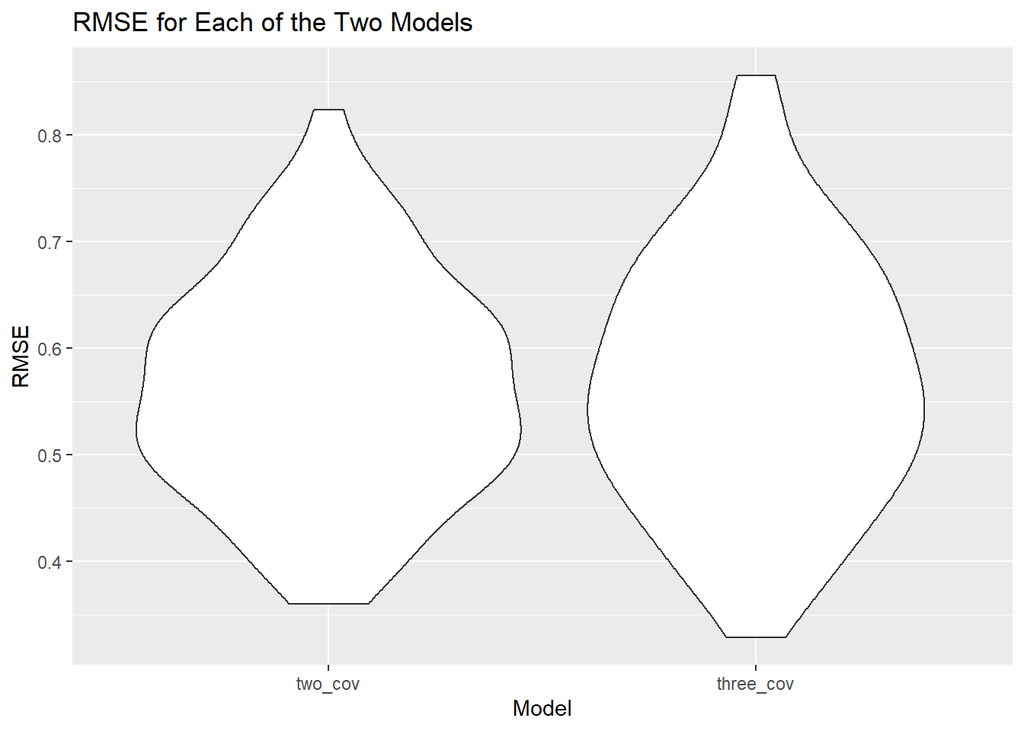

```r
library(modelr)
set.seed(1)
final_model_no_DC <- lm(hate_crimes_log ~ gini_index + perc_pop_hs, data = hate_crimes_df_no_DC )
#summary(final_model_no_DC)

final_model_no_DC_unemploy <- lm(hate_crimes_log ~ gini_index + perc_pop_hs + unemployment, data = hate_crimes_df_no_DC)
#summary(final_model_no_DC_unemploy)

cv_df =
  crossv_mc(hate_crimes_df_no_DC, 100) %>%
  mutate(
    train = map(train, as_tibble),
    test = map(test, as_tibble))

cv_df =
  cv_df %>%
  mutate(
    two_cov_model = map(train, ~lm(hate_crimes_log ~ gini_index + perc_pop_hs, data = .x)),
    three_cov_model = map(train, ~lm(hate_crimes_log ~ gini_index + perc_pop_hs + unemployment, data = .x))
  ) %>%

  mutate(
    rmse_two_cov = map2_dbl(two_cov_model, test, ~rmse(model = .x, data = .y)),
    rmse_three_cov = map2_dbl(three_cov_model, test, ~rmse(model = .x, data = .y))
    )

cv_df %>%
  select(starts_with("rmse")) %>%
  pivot_longer(
    everything(),
    names_to = "model",
    values_to = "rmse",
    names_prefix = "rmse_") %>%
  mutate(model = fct_inorder(model)) %>%
  ggplot(aes(x = model, y = rmse)) + geom_violin() +
  labs(
    title = "RMSE for Each of the Two Models",
    x = "Model",
    y = "RMSE"
  )
```

Stratify based on significant interactions and comment

Model diagnostics

Duplicate code with and without DC and comment on the effect of the outlier.

Final writeup!